# Lab 2 Assignment: Basics of Statistics in R

SOC 325: Quantified-Self

2023-10-09

# Getting started: Editing and running code

There are several ways we can run code:

- Highlight lines in the editor window and click **Run** at the top or hit `Ctrl` + `Enter` or `CMD` + `Enter` (Mac) to run them all.
- With your caret on a line you want to run, hit `Ctrl` + `Enter` or `CMD` + `Enter` (Mac). Note your caret moves to the next line, so you can run code sequentially with repeated presses.
- Type individual lines in the console and press enter.
- In R Markdown documents, click within a code chunk and click the green arrow to run the chunk. The button beside that runs all prior chunks.

# What is data? What is statistics?

How does data fit into the scientific process?

1. Identify a question or problem (e.g. how fast did I run this month?)
2. Collect relevant data on the topic (e.g. record runs for a month)
3. Analyze the data
4. Form a conclusion

> Statistics as a subject focuses on making stages 2-4 objective, rigorous, and efficient. That is, statistics has three primary components: How best can we collect data? How should it be analyzed? And what can we infer from the analysis?
- Data: Measurement of an item/event
  - e.g., height, weight
- Statistic: Functions on the data
  - e.g., mean, meadian, mode, min, max
- Probability (distribution): Probability is the measure of the likelihood that an event will occur (Wikipedia)

`airquality` Daily air quality measurements in New York, May to September 1973. Use `ggplot` to plot `Ozone` versus the `Wind` with a `smoother`.

YOUR SOLUTION HERE

END OF YOUR SOLUTION HERE

## Experiments

**Treatment group** Patients in the treatment group received a stent and medical management. The medical management included medications, management of risk factors, and help in lifestyle modification.

**Control group** Patients in the control group received the same medical manage- ment as the treatment group but did not receive stents.

```r
library(infer)
data(gss)

# calculate the observed statistic
observed_statistic <- gss %>%
  specify(hours ~ college) %>%
  calculate(stat = "diff in means", order = c("degree", "no degree"))

observed_statistic
```

```
## Response: hours (numeric)
## Explanatory: college (factor)
## # A tibble: 1 × 1
##    stat
##   <dbl>
## 1  1.54
```

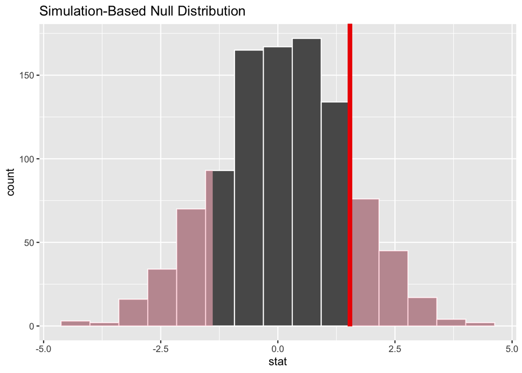

```r
# generate the null distribution with randomization
null_dist_2_sample <- gss %>%
  specify(hours ~ college) %>%
  hypothesize(null = "independence") %>%
  generate(reps = 1000, type = "permute") %>%
  calculate(stat = "diff in means", order = c("degree", "no degree"))

# visualize the randomization-based null distribution and test statistic!
null_dist_2_sample %>%
  visualize() +
  shade_p_value(observed_statistic,
                direction = "two-sided")
```

```r
# calculate the p value from the randomization-based null
# distribution and the observed statistic
p_value_2_sample <- null_dist_2_sample %>%
  get_p_value(obs_stat = observed_statistic,
              direction = "two-sided")

p_value_2_sample
```

```
## # A tibble: 1 × 1
##   p_value
##     <dbl>
## 1   0.288
```

```r
t_test(x = gss,
       formula = hours ~ college,
       order = c("degree", "no degree"),
       alternative = "two-sided")
```

```
## # A tibble: 1 × 7
##   statistic  t_df p_value alternative estimate lower_ci upper_ci
##       <dbl> <dbl>   <dbl> <chr>          <dbl>    <dbl>    <dbl>
## 1      1.12  366.   0.264 two.sided       1.54    -1.16     4.24
```

Repeat the above, but with `sex` instead of `college`.

YOUR SOLUTION HERE

END OF YOUR SOLUTION HERE

## Five Named Graphs

1. scatterplots
2. linegraphs
3. boxplots
4. histograms
5. barplots

Let’s consider *flights*, filter `carrier` by `DL`. Plot `dep_delay` by `arr_delay`.

YOUR SOLUTION HERE

```r
library(nycflights13)
data(flights)
#all_dl_flights<-flights%>%filter()
```

```r
## Scatter Plot
```

END OF YOUR SOLUTION HERE

### Linegraphs

Our focus now turns to the temp variable in this weather data-set.

```r
data(weather)
head(weather)
```

```
## # A tibble: 6 × 15
##   origin  year month   day  hour  temp  dewp humid wind_dir wind_speed wind_gust
##   <chr>  <int> <int> <int> <int> <dbl> <dbl> <dbl>    <dbl>      <dbl>     <dbl>
## 1 EWR     2013     1     1     1  39.0  26.1  59.4      270      10.4         NA
## 2 EWR     2013     1     1     2  39.0  27.0  61.6      250       8.06        NA
## 3 EWR     2013     1     1     3  39.0  28.0  64.4      240      11.5         NA
## 4 EWR     2013     1     1     4  39.9  28.0  62.2      250      12.7         NA
## 5 EWR     2013     1     1     5  39.0  28.0  64.4      260      12.7         NA
## 6 EWR     2013     1     1     6  37.9  28.0  67.2      240      11.5         NA
## # ℹ 4 more variables: precip <dbl>, pressure <dbl>, visib <dbl>,
## #   time_hour <dttm>
```

Plot `weather` `dew` by `temp`.

YOUR SOLUTION HERE

```r
## Line plot
```

END OF YOUR SOLUTION HERE

### Histograms

Histogram `weather` data set and variable `humid`.

YOUR SOLUTION HERE

```r
## Histogram
```

END OF YOUR SOLUTION HERE

# Review of Mathematics

## Scalar

Scalar. For our purposes this means, effectively, a single number in vector, e.g. $5$.

Compute 1 times 2, and 2 devided by 3.

YOUR SOLUTION HERE

END OF YOUR SOLUTION HERE

## Vector

- Vector. For our purposes this means a sequence of data of the same type.
- Created in r with `c()`.
- Checked with `is.vector()`

Create a vector of five numbers and verify it is a vector.

YOUR SOLUTION HERE

END OF YOUR SOLUTION HERE

## Matrix and data.frame

- Matrix: For our purposes this means a collection of vectors.
- `data.frame` is a special R object that is a matrix which can have different types of variables on the columns.

Create a data.frame composed of a vector of numbers and vector of letters.

YOUR SOLUTION HERE

END OF YOUR SOLUTION HERE

# Statistical Inference

Example of Regression `summary`

```r
summary(lm(rating~complaints,data=attitude))
```

```
##
## Call:
## lm(formula = rating ~ complaints, data = attitude)
##
## Residuals:
##      Min       1Q   Median       3Q      Max
## -12.8799  -5.9905   0.1783   6.2978   9.6294
##
## Coefficients:
##             Estimate Std. Error t value Pr(>|t|)
## (Intercept) 14.37632    6.61999   2.172   0.0385 *
## complaints   0.75461    0.09753   7.737 1.99e-08 ***
## ---
## Signif. codes:  0 '***' 0.001 '**' 0.01 '*' 0.05 '.' 0.1 ' ' 1
##
## Residual standard error: 6.993 on 28 degrees of freedom
## Multiple R-squared:  0.6813, Adjusted R-squared:  0.6699
## F-statistic: 59.86 on 1 and 28 DF,  p-value: 1.988e-08
```

Compute the following statistics:

- t-test between `raiting` and `learning`.
- correlation test between `complaints` and `advance`
- regression between `raiting` and `learning`

YOUR SOLUTION HERE

END OF YOUR SOLUTION HERE